# EDA on Googleplaystore

## What is EDA?

**EDA (Exploratory Data Analysis)** is a crucial step in the data analysis process that involves summarizing the main characteristics of a dataset, often using visual methods. The goal is to explore the data before making any assumptions or building models. ___________________________________________________________________________________________________________________________________________________________________________________________________

### Key Objectives of EDA:

1. **Understand the Structure of Data**: EDA helps in understanding the shape, size, and overall structure of the dataset.
2. **Detect Missing or Outlier Values**: It helps identify any missing values, errors, or outliers that could affect the analysis.
3. **Identify Patterns and Relationships**: EDA looks for trends, correlations, or any hidden patterns in the data.
4. **Validate Assumptions**: This step checks whether the data meets the assumptions for further statistical analysis or modeling.

### Techniques in EDA:

- **Summary Statistics**: Functions like `.describe()`, `.info()` to get mean, median, standard deviation, etc.
- **Visualizations**:
  - **Histograms** and **Density Plots** for distribution of data.
  - **Box Plots** to identify outliers.
  - **Scatter Plots** to understand relationships between variables.
  - **Correlation Heatmaps** to analyze relationships between multiple variables.

EDA is often the first step when working with a dataset, enabling you to make better-informed decisions on how to proceed with data cleaning, transformation, and modeling. ______________________________________________________________________________________________________________________________________________________________________________________________________

**Find Dataset** : https://www.kaggle.com/datasets/lava18/google-play-store-apps

# Information About My Dataset

The dataset has 10,841 rows and 13 columns. This indicates a large dataset with detailed information on a wide range of apps from the Google Play Store. The columns are:

1. **App**: Name of the app.
2. **Category**: Category of the app (e.g., Games, Productivity).
3. **Rating**: Rating given to the app, usually out of 5.
4. **Reviews**: Number of reviews the app has received.
5. **Size**: Size of the app.
6. **Installs**: Number of installs (often represented in ranges, e.g., 1,000+).
7. **Type**: Paid or Free app.
8. **Price**: Price of the app if it is paid.
9. **Content Rating**: Audience suitability (e.g., Everyone, Teen, Mature).
10. **Genres**: Specific genre(s) of the app.
11. **Last Updated**: Date when the app was last updated.
12. **Current Ver**: Current version of the app.
13. **Android Ver**: Minimum Android version required ton the app.

# Importing packages and dataset

```python
#import Libraries
import pandas as pd
import numpy as np
import matplotlib.pyplot as plt
import seaborn as sns
import matplotlib
%matplotlib inline
import warnings
warnings.filterwarnings("ignore")
```

```python
gpa_df = pd.read_csv("googleplaystore.csv")
gpa_df.head()
```

|  | App | Category | Rating | Reviews | Size | Installs | Type | Price | Content Rating | Genres | Last Updated | Current Ver | Android Ver |
| --- | --- | --- | --- | --- | --- | --- | --- | --- | --- | --- | --- | --- | --- |
| 0 | Photo Editor & Candy Camera & Grid & ScrapBook | ART_AND_DESIGN | 4.1 | 159 | 19M | 10,000+ | Free | 0 | Everyone | Art & Design | January 7, 2018 | 1.0.0 | 4.0.3 and up |
| 1 | Coloring book moana | ART_AND_DESIGN | 3.9 | 967 | 14M | 500,000+ | Free | 0 | Everyone | Art & Design;Pretend Play | January 15, 2018 | 2.0.0 | 4.0.3 and up |
| 2 | U Launcher Lite – FREE Live Cool Themes, Hide ... | ART_AND_DESIGN | 4.7 | 87510 | 8.7M | 5,000,000+ | Free | 0 | Everyone | Art & Design | August 1, 2018 | 1.2.4 | 4.0.3 and up |
| 3 | Sketch - Draw & Paint | ART_AND_DESIGN | 4.5 | 215644 | 25M | 50,000,000+ | Free | 0 | Teen | Art & Design | June 8, 2018 | Varies with device | 4.2 and up |
| 4 | Pixel Draw - Number Art Coloring Book | ART_AND_DESIGN | 4.3 | 967 | 2.8M | 100,000+ | Free | 0 | Everyone | Art & Design;Creativity | June 20, 2018 | 1.1 | 4.4 and up |

- The head() function in Python, particularly with pandas, is used to display the first 5 rows of a DataFrame

```python
gpa_df.tail()
```

|  | App | Category | Rating | Reviews | Size | Installs | Type | Price | Content Rating | Genres | Last Updated | Current Ver | Android Ver |
| --- | --- | --- | --- | --- | --- | --- | --- | --- | --- | --- | --- | --- | --- |
| 10836 | Sya9a Maroc - FR | FAMILY | 4.5 | 38 | 53M | 5,000+ | Free | 0 | Everyone | Education | July 25, 2017 | 1.48 | 4.1 and up |
| 10837 | Fr. Mike Schmitz Audio Teachings | FAMILY | 5.0 | 4 | 3.6M | 100+ | Free | 0 | Everyone | Education | July 6, 2018 | 1.0 | 4.1 and up |
| 10838 | Parkinson Exercices FR | MEDICAL | NaN | 3 | 9.5M | 1,000+ | Free | 0 | Everyone | Medical | January 20, 2017 | 1.0 | 2.2 and up |
| 10839 | The SCP Foundation DB fr nn5n | BOOKS_AND_REFERENCE | 4.5 | 114 | Varies with device | 1,000+ | Free | 0 | Mature 17+ | Books & Reference | January 19, 2015 | Varies with device | Varies with device |
| 10840 | iHoroscope - 2018 Daily Horoscope & Astrology | LIFESTYLE | 4.5 | 398307 | 19M | 10,000,000+ | Free | 0 | Everyone | Lifestyle | July 25, 2018 | Varies with device | Varies with device |

- The tail() function is used to display the last 5 rows of the DataFrame

# Data Preprocessing and Cleaning

- Data preparation and cleaning are crucial steps in data analysis to ensure that the dataset is accurate, consistent, and ready for analysis.

```python
gpa_df.shape
```

```
(10841, 13)
```

- If the output of gpa_df.shape is (10841, 13), it means there are 10,841 rows and 13 columns in the DataFrame.

```python
gpa_df.columns
```

```
Index(['App', 'Category', 'Rating', 'Reviews', 'Size', 'Installs', 'Type',
       'Price', 'Content Rating', 'Genres', 'Last Updated', 'Current Ver',
       'Android Ver'],
      dtype='object')
```

- The code gpa_df.columns returns an index object that lists all the column names of the DataFrame gpa_df.
- Random sample of rows or columns from a DataFrame

```python
gpa_df.info()
```

```
<class 'pandas.core.frame.DataFrame'>
RangeIndex: 10841 entries, 0 to 10840
Data columns (total 13 columns):
 #   Column          Non-Null Count  Dtype
---  ------          --------------  -----
 0   App             10841 non-null  object
 1   Category        10841 non-null  object
 2   Rating          9367 non-null   float64
 3   Reviews         10841 non-null  object
 4   Size            10841 non-null  object
 5   Installs        10841 non-null  object
 6   Type            10840 non-null  object
 7   Price           10841 non-null  object
 8   Content Rating  10840 non-null  object
 9   Genres          10841 non-null  object
 10  Last Updated    10841 non-null  object
 11  Current Ver     10833 non-null  object
 12  Android Ver     10838 non-null  object
dtypes: float64(1), object(12)
memory usage: 1.1+ MB
```

The gpa_df.info() function provides a summary of the DataFrame's structure, including:

- **Number of entries (rows)**: Total number of data points in the dataset.
- **Column names**: A list of all the column names in the DataFrame.
- **Non-null count**: The number of non-null values in each column (i.e., values that are not missing).
- **Data types**: The data type of each column (e.g., int64, float64, object).
- **Memory usage**: The total memory used by the DataFrame.

```python
gpa_df.describe()
```

|  | Rating |
| --- | --- |
| count | 9367.000000 |
| mean | 4.193338 |
| std | 0.537431 |
| min | 1.000000 |
| 25% | 4.000000 |
| 50% | 4.300000 |
| 75% | 4.500000 |
| max | 19.000000 |

- The **describe()** function in pandas provides a summary of statistics for numerical columns in a DataFrame. It includes measures like count, mean, standard deviation, minimum, maximum, and percentiles.

```python
gpa_df.isnull().sum()
```

```
App                  0
Category             0
Rating            1474
Reviews              0
Size                 0
Installs             0
Type                 1
Price                0
Content Rating       1
Genres               0
Last Updated         0
Current Ver          8
Android Ver          3
dtype: int64
```

- The **gpa_df.isnull().sum()** command will return a Series showing the count of missing (NaN) values for each column in your DataFrame. This helps identify which columns have missing values and how many there are. Here’s how to interpret the output:
- **If the output is all zeros**, it means there are no missing values in any of the columns.
- **If there are non-zero values**, it indicates the number of missing values per column. You will need to address these missing values, either by filling them in or removing the affected rows.

```python
gpa_df["Rating"].unique()
```

```
array([ 4.1,  3.9,  4.7,  4.5,  4.3,  4.4,  3.8,  4.2,  4.6,  3.2,  4. ,
        nan,  4.8,  4.9,  3.6,  3.7,  3.3,  3.4,  3.5,  3.1,  5. ,  2.6,
        3. ,  1.9,  2.5,  2.8,  2.7,  1. ,  2.9,  2.3,  2.2,  1.7,  2. ,
        1.8,  2.4,  1.6,  2.1,  1.4,  1.5,  1.2, 19. ])
```

- The **unique()** function in pandas returns the unique values present in a specific column.
- When you run **gpa_df["Rating"].unique()**, it will return all the unique values in the "Rating" column of your dataset.

```python
gpa_df["Category"].unique()
```

```
array(['ART_AND_DESIGN', 'AUTO_AND_VEHICLES', 'BEAUTY',
       'BOOKS_AND_REFERENCE', 'BUSINESS', 'COMICS', 'COMMUNICATION',
       'DATING', 'EDUCATION', 'ENTERTAINMENT', 'EVENTS', 'FINANCE',
       'FOOD_AND_DRINK', 'HEALTH_AND_FITNESS', 'HOUSE_AND_HOME',
       'LIBRARIES_AND_DEMO', 'LIFESTYLE', 'GAME', 'FAMILY', 'MEDICAL',
       'SOCIAL', 'SHOPPING', 'PHOTOGRAPHY', 'SPORTS', 'TRAVEL_AND_LOCAL',
       'TOOLS', 'PERSONALIZATION', 'PRODUCTIVITY', 'PARENTING', 'WEATHER',
       'VIDEO_PLAYERS', 'NEWS_AND_MAGAZINES', 'MAPS_AND_NAVIGATION',
       '1.9'], dtype=object)
```

- When you run **gpa_df["Category"].unique()**, it will return all the unique values in the "Category" column of your dataset.

```python
gpa_df.groupby(by = 'Category') ["Rating"].mean()
```

```
Category
1.9                    19.000000
ART_AND_DESIGN          4.358065
AUTO_AND_VEHICLES       4.190411
BEAUTY                  4.278571
BOOKS_AND_REFERENCE     4.346067
BUSINESS                4.121452
COMICS                  4.155172
COMMUNICATION           4.158537
DATING                  3.970769
EDUCATION               4.389032
ENTERTAINMENT           4.126174
EVENTS                  4.435556
FAMILY                  4.192272
FINANCE                 4.131889
FOOD_AND_DRINK          4.166972
GAME                    4.286326
HEALTH_AND_FITNESS      4.277104
HOUSE_AND_HOME          4.197368
LIBRARIES_AND_DEMO      4.178462
LIFESTYLE               4.094904
MAPS_AND_NAVIGATION     4.051613
MEDICAL                 4.189143
NEWS_AND_MAGAZINES      4.132189
PARENTING               4.300000
PERSONALIZATION         4.335987
PHOTOGRAPHY             4.192114
PRODUCTIVITY            4.211396
SHOPPING                4.259664
SOCIAL                  4.255598
SPORTS                  4.223511
TOOLS                   4.047411
TRAVEL_AND_LOCAL        4.109292
VIDEO_PLAYERS           4.063750
WEATHER                 4.244000
Name: Rating, dtype: float64
```

- The **groupby()** function in pandas allows you to group data by a specific column and perform aggregate functions like mean() on another column.
- In your case, you want to group the dataset by the **"Category"** column and calculate the mean of the **"Rating"** column for each category.

```python
gpa_df["Rating"].mean()
```

```
np.float64(4.193338315362443)
```

- **gpa_df["Rating"].mean():** Calculates the average (mean) value of the **"Rating"** column.

This value represents the overall average rating for all apps in your dataset.

```python
def imp_rating(category_classes):
    for category_class in category_classes:
        sub_set=gpa_df['Category']==category_class
        mean=gpa_df[gpa_df["Category"]==category_class]["Rating"].mean()
        gpa_df.loc[sub_set,"Rating"]=gpa_df.loc[sub_set,"Rating"].fillna(mean)
```

```python
category_classes = ['ART_AND_DESIGN', 'AUTO_AND_VEHICLES', 'BEAUTY',
       'BOOKS_AND_REFERENCE', 'BUSINESS', 'COMICS', 'COMMUNICATION',
       'DATING', 'EDUCATION', 'ENTERTAINMENT', 'EVENTS', 'FINANCE',
       'FOOD_AND_DRINK', 'HEALTH_AND_FITNESS', 'HOUSE_AND_HOME',
       'LIBRARIES_AND_DEMO', 'LIFESTYLE', 'GAME', 'FAMILY', 'MEDICAL',
       'SOCIAL', 'SHOPPING', 'PHOTOGRAPHY', 'SPORTS', 'TRAVEL_AND_LOCAL',
       'TOOLS', 'PERSONALIZATION', 'PRODUCTIVITY', 'PARENTING', 'WEATHER',
       'VIDEO_PLAYERS', 'NEWS_AND_MAGAZINES', 'MAPS_AND_NAVIGATION',
       '1.9']
imp_rating(category_classes)
```

- Loop Through Categories:
  - Iterate over each category in the category_classes list.
- Create a Boolean Mask:
  - sub_set is a boolean mask that selects rows where the "Category" matches the current category in the loop.
- Calculate Mean Rating:
  - Compute the mean rating for the current category.
- Fill Missing Values:
  - Use fillna() to replace NaN values in the "Rating" column with the computed mean for that category.

```python
gpa_df.isnull().sum()
```

```
App               0
Category          0
Rating            0
Reviews           0
Size              0
Installs          0
Type              1
Price             0
Content Rating    1
Genres            0
Last Updated      0
Current Ver       8
Android Ver       3
dtype: int64
```

- The isnull().sum() method in pandas is used to count the number of missing (NaN) values in each column of the DataFrame.

```python
gpa_df['Type'] = gpa_df['Type'].fillna(value=0)
```

- The line of code you provided is intended to fill missing values (NaN) in the "Type" column with 0. However, the "Type" column is likely categorical (e.g., 'Free', 'Paid'), so replacing missing values with 0 might not be appropriate.

```python
gpa_df.isnull().sum()
```

```
App               0
Category          0
Rating            0
Reviews           0
Size              0
Installs          0
Type              0
Price             0
Content Rating    1
Genres            0
Last Updated      0
Current Ver       8
Android Ver       3
dtype: int64
```

```python
gpa_df['Content Rating'] = gpa_df['Content Rating'].fillna(value=0)
```

- Filling missing values in the "Content Rating" column with 0 might not be appropriate since "Content Rating" typically contains categorical values such as 'Everyone', 'Teen', 'Mature 17+', etc. Using 0 could introduce inconsistencies or errors in your data.

```python
gpa_df.isnull().sum()
```

```
App               0
Category          0
Rating            0
Reviews           0
Size              0
Installs          0
Type              0
Price             0
Content Rating    0
Genres            0
Last Updated      0
Current Ver       8
Android Ver       3
dtype: int64
```

```python
gpa_df['Current Ver'] = gpa_df['Current Ver'].fillna(value=0)
```

- Filling missing values in the "Current Ver" column with 0 might not be appropriate since "Current Ver" typically contains version numbers in a string format (e.g., '1.0', '2.3.4'). Using 0 can create inconsistencies in this column.

```python
gpa_df.isnull().sum()
```

[output not shown]

```python
gpa_df['Android Ver'] = gpa_df['Android Ver'].fillna(value=0)
```

- Filling missing values in the "Android Ver" column with 0 might not be suitable since "Android Ver" typically contains version numbers in a string format (e.g., '4.4', '5.0', '6.0.1'). Using 0 can lead to inconsistencies in your data.

```python
gpa_df.isnull().sum()
```

[output not shown]

```python
gpa_df.columns
```

```
Index(['App', 'Category', 'Rating', 'Reviews', 'Size', 'Installs', 'Type',
       'Price', 'Content Rating', 'Genres', 'Last Updated', 'Current Ver',
       'Android Ver'],
      dtype='object')
```

- To view the column names in your DataFrame, you can use the columns attribute.

# Exploratory Analysis and Visualization

- "The graphical representation of data to identify patterns, trends, and insights through visual elements such as charts, graphs, and maps."

## 1. Distribution of App Ratings

- Visualization: Histogram
- Purpose: To observe how app ratings are distributed across the dataset (e.g., are most apps rated between 4 and 5 stars?).

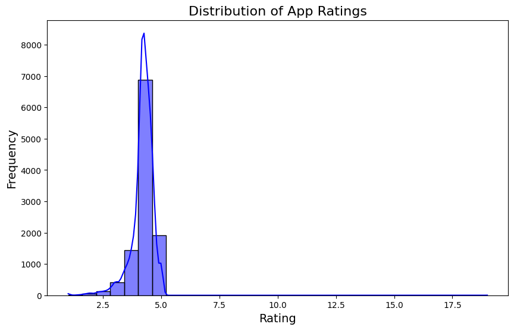

```python
plt.figure(figsize=(10,6))
sns.histplot(gpa_df['Rating'].dropna(), bins=30, kde=True, color='blue')
plt.title('Distribution of App Ratings', fontsize=16)
plt.xlabel('Rating', fontsize=14)
plt.ylabel('Frequency', fontsize=14)
plt.show();
```

- The histogram shows the frequency distribution of the app ratings, with each bar representing the count of ratings that fall within a specific range.
- The KDE curve provides a smoothed line to show the overall distribution trend, giving an idea of how the data is distributed across different rating values.
- The x-axis represents the rating values (e.g., IMDB ratings, app ratings), and the y-axis represents the frequency or number of occurrences for each rating.
- `The plot helps visualize the spread and concentration of ratings in your dataset, showing whether most ratings are high, low, or evenly distributed.`

## 2. Category-wise Distribution of Apps

- Visualization: Bar Plot
- Purpose: To analyze the number of apps across different categories (e.g., games, education, business, etc.).

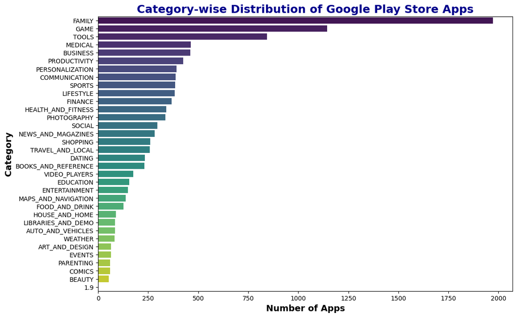

```python
category_counts = df['Category'].value_counts()
plt.figure(figsize=(12,8))
sns.barplot(x=category_counts.values, y=category_counts.index, palette='viridis')
plt.title('Category-wise Distribution of Google Play Store Apps', fontsize=18, fontweight='bold', color='darkblue')
plt.xlabel('Number of Apps', fontsize=14, fontweight='bold')
plt.ylabel('Category', fontsize=14, fontweight='bold')
plt.show();
```

- The horizontal bar plot shows the number of apps in each category.
- The y-axis lists the categories (e.g., Games, Tools, Productivity) found in the Google Play Store.
- The x-axis shows the number of apps in each category, allowing for easy comparison across categories.
- The color gradient (using the viridis palette) enhances the visual appeal and highlights differences in app counts across categories.
- `This plot helps to quickly identify which categories have the most or least apps, providing insights into the app distribution across various categories on the Google Play Store.`

## 3. Free vs. Paid Apps Distribution

- Visualization: Pie Chart
- Purpose: To show the proportion of free versus paid apps in the store.

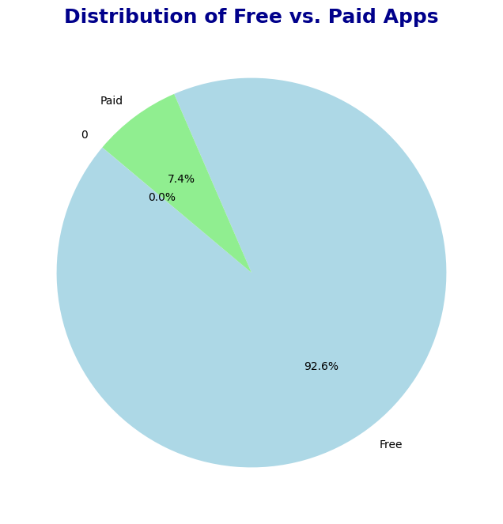

```python
app_type_counts = df['Type'].value_counts()

plt.figure(figsize=(8, 8))

plt.pie(app_type_counts, labels=app_type_counts.index, autopct='%1.1f%%', colors=['lightblue', 'lightgreen'], startangle=140)

plt.title('Distribution of Free vs. Paid Apps', fontsize=18, fontweight='bold', color='darkblue')

plt.show()
```

## 4. Number of Apps in Each Content Rating

- Visualization: Countplot
- Purpose: To visualize the distribution of apps across different content ratings, highlighting which ratings are most common.

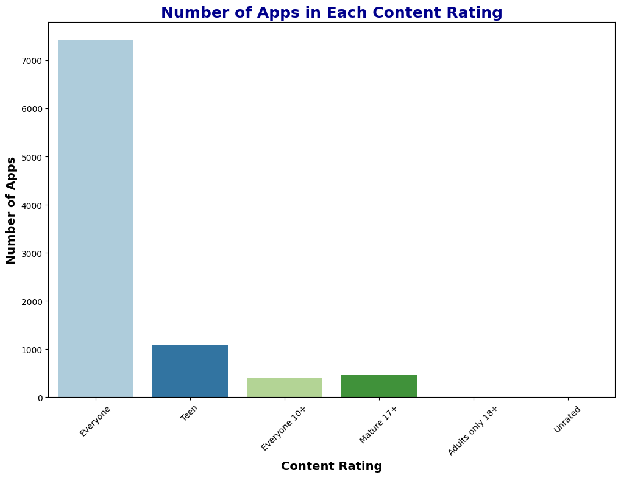

```python
df = df.dropna(subset=['Content Rating'])

plt.figure(figsize=(12, 8))

sns.countplot(x='Content Rating', data=df, palette='Paired')

plt.title('Number of Apps in Each Content Rating', fontsize=18, fontweight='bold', color='darkblue')
plt.xlabel('Content Rating', fontsize=14, fontweight='bold')
plt.ylabel('Number of Apps', fontsize=14, fontweight='bold')

plt.xticks(rotation=45)
plt.show()
```

- The count plot shows the number of apps available for each content rating (e.g., Everyone, Teen, Mature, Adults Only).
- The x-axis lists the content rating categories, while the y-axis shows the number of apps in each category.
- Each bar represents the count of apps for a specific content rating, and the distinct colors (from the Paired palette) make it easy to differentiate between categories.
- Rotating the x-axis labels helps ensure that longer category names (if present) are readable.
- `This plot provides a clear overview of the distribution of apps based on their content ratings, highlighting which content rating categories have the most or fewest apps.`

## 5. Number of Apps by Genre

- Visualization: Countplot
- Purpose: To visualize the distribution of the number of apps across different genres to identify which genres are most prevalent.

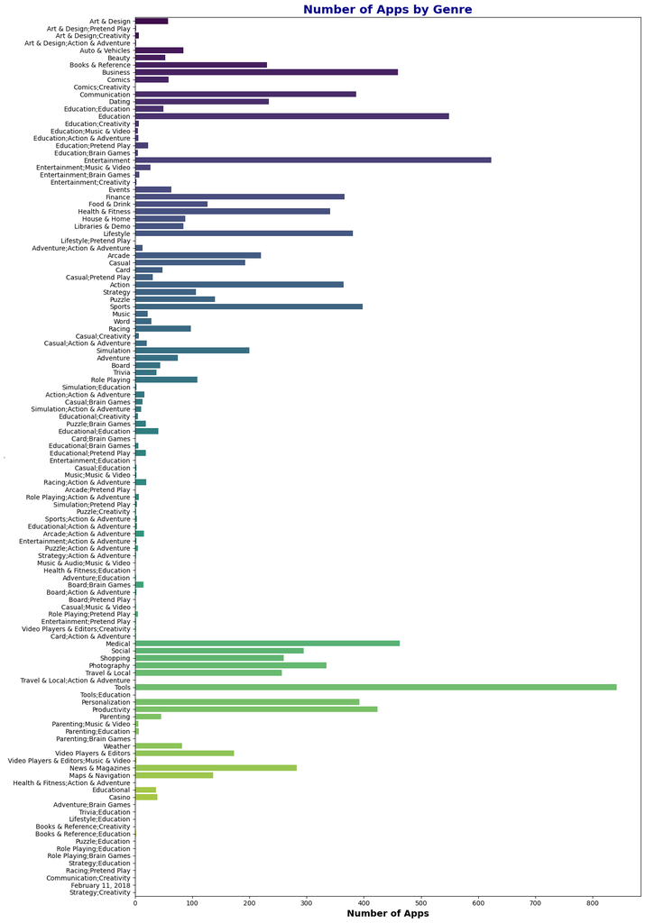

```python
plt.figure(figsize=(14, 20))
sns.countplot(y='Genres', data=df, palette='viridis')
plt.title('Number of Apps by Genre', fontsize=18, fontweight='bold', color='darkblue')
plt.xlabel('Number of Apps', fontsize=14, fontweight='bold')
plt.ylabel('Genre', fontsize=1, fontweight='bold')
plt.show()
```

- The count plot will display the number of apps in each genre on the x-axis, with each genre listed on the y-axis.
- The bars represent the count of apps in each genre, and the colors from the viridis palette make the chart more visually engaging.
- The x-axis shows the number of apps for each genre, and the y-axis lists the genre names.

## 6. Top 10 Categories by Number of Apps

- Visualization: Barplot
- Purpose: Highlight the top categories with the most apps.

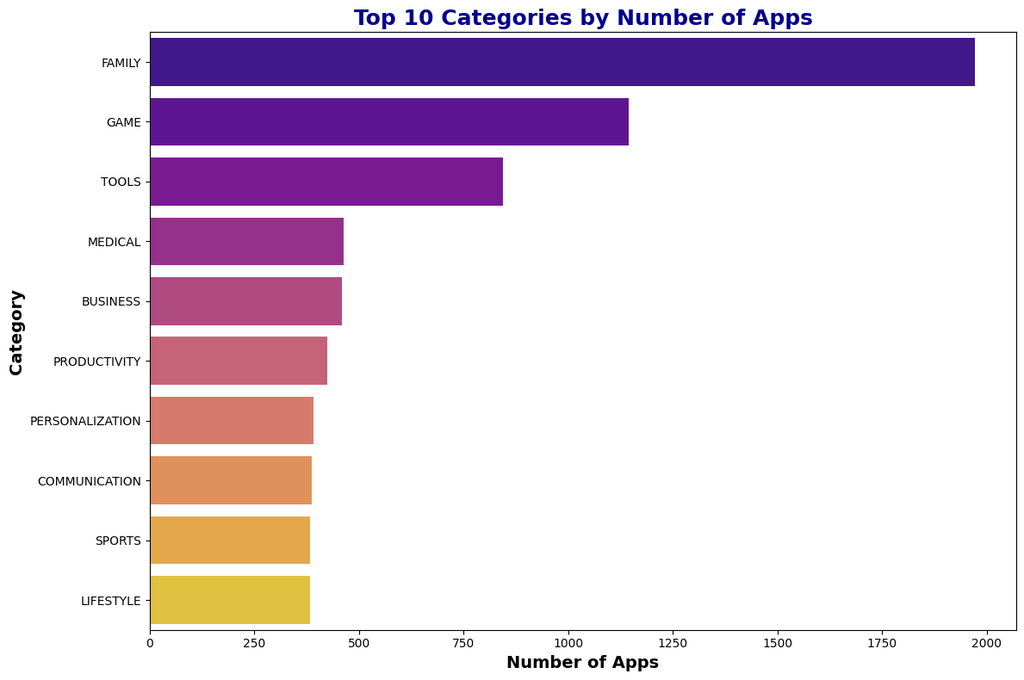

```python
category_counts = df['Category'].value_counts().head(10)

plt.figure(figsize=(12, 8))

# Bar plot for top 10 categories
sns.barplot(x=category_counts.values, y=category_counts.index, palette='plasma')

# Customize the title and axis labels
plt.title('Top 10 Categories by Number of Apps', fontsize=18, fontweight='bold', color='darkblue')
plt.xlabel('Number of Apps', fontsize=14, fontweight='bold')
plt.ylabel('Category', fontsize=14, fontweight='bold')

# Show the plot
plt.tight_layout()
plt.show()
```

- The bar plot will show the top 10 categories with the highest number of apps.
- Each bar represents the count of apps in one of the top 10 categories, with the length of the bar corresponding to the number of apps.
- The x-axis displays the number of apps, and the y-axis lists the category names.

## 7. Top 10 Apps with Highest Ratings

- Visualization: Barplot
- Purpose: Identify the highest-rated apps.

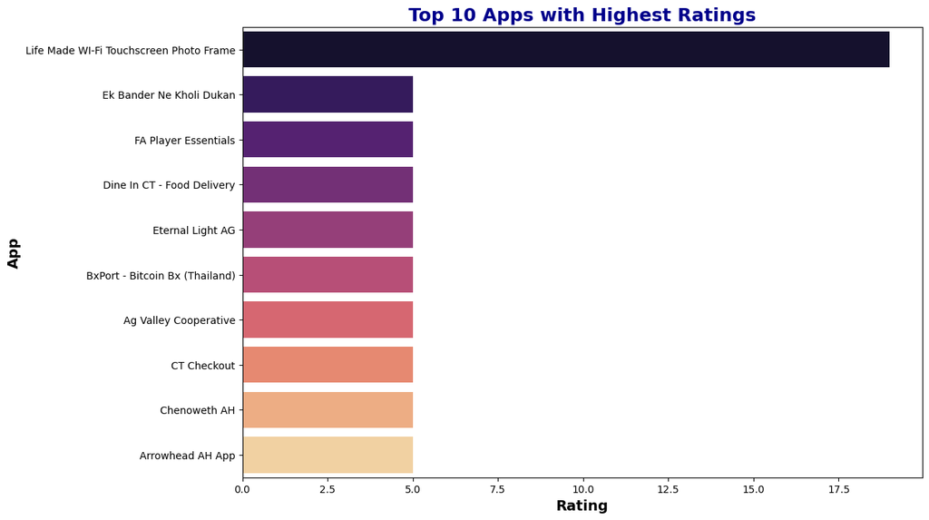

```python
df = df.dropna(subset=['Rating'])
top_rated_apps = df[['App', 'Rating']].sort_values(by='Rating', ascending=False).head(10)
plt.figure(figsize=(12, 8))
sns.barplot(x='Rating', y='App', data=top_rated_apps, palette='magma')
plt.title('Top 10 Apps with Highest Ratings', fontsize=18, fontweight='bold', color='darkblue')
plt.xlabel('Rating', fontsize=14, fontweight='bold')
plt.ylabel('App', fontsize=14, fontweight='bold')
plt.show()
```

- The bar plot will display the top 10 apps with the highest ratings.
- Each bar represents an app, with the length of the bar corresponding to the app's rating.
- The x-axis shows the ratings, and the y-axis lists the app names.

## 8. Number of Apps by Rating Category

- Visualization: Countplot

Purpose Understand how apps are distributed across rating categories..

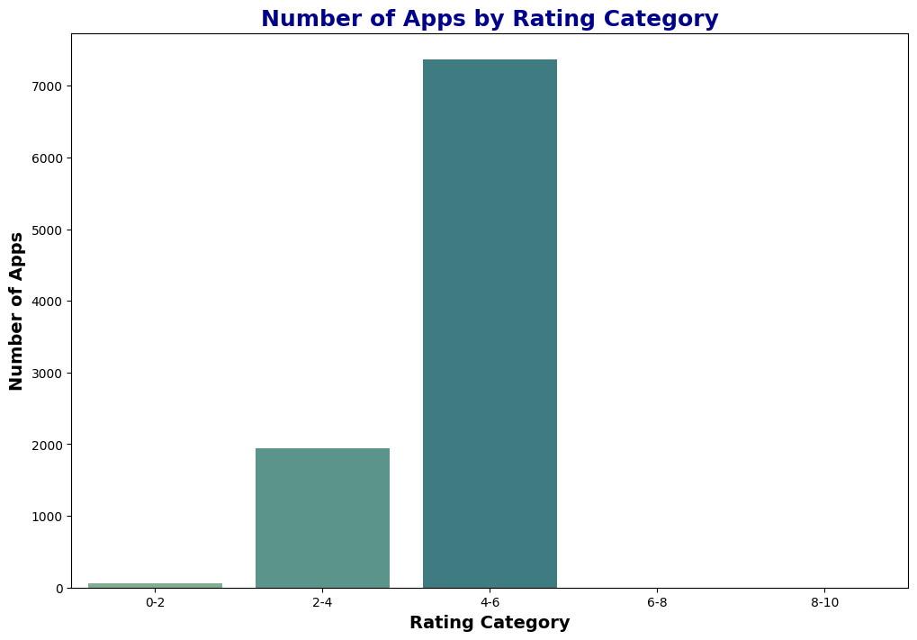

```python
df = df.dropna(subset=['Rating'])
bins = [0, 2, 4, 6, 8, 10]
labels = ['0-2', '2-4', '4-6', '6-8', '8-10']
df['Rating Category'] = pd.cut(df['Rating'], bins=bins, labels=labels, right=False)
plt.figure(figsize=(12, 8))
sns.countplot(x='Rating Category', data=df, palette='crest')
plt.title('Number of Apps by Rating Category', fontsize=18, fontweight='bold', color='darkblue')
plt.xlabel('Rating Category', fontsize=14, fontweight='bold')
plt.ylabel('Number of Apps', fontsize=14, fontweight='bold')
plt.show()
```

- The count plot will display the number of apps in each rating category.
- The x-axis shows the rating categories (e.g., 0-2, 2-4, etc.), and the y-axis shows the number of apps in each category.
- The bars represent the count of apps falling into each rating category, with the colors from the crest palette enhancing the visual appeal.
- `This plot helps to understand the distribution of app ratings across different categories, showing how many apps fall into each rating range.`

## 9. App Ratings by Content Rating

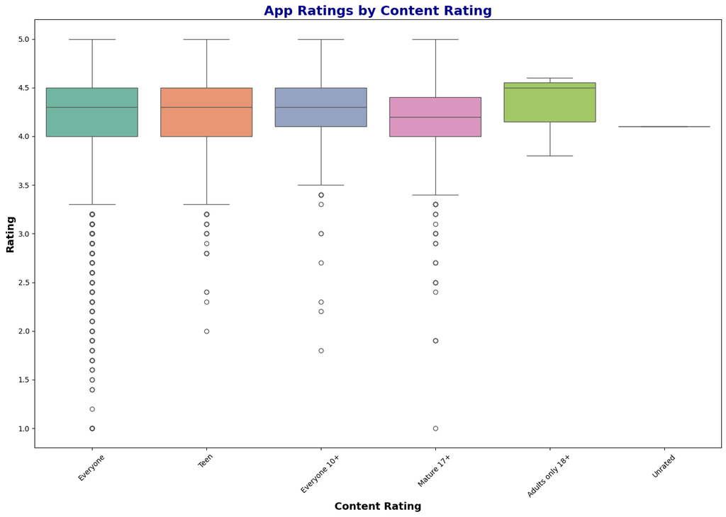

```python
df = df.dropna(subset=['Rating', 'Content Rating'])
plt.figure(figsize=(14, 10))
sns.boxplot(x='Content Rating', y='Rating', data=df, palette='Set2')
plt.title('App Ratings by Content Rating', fontsize=18, fontweight='bold', color='darkblue')
plt.xlabel('Content Rating', fontsize=14, fontweight='bold')
plt.ylabel('Rating', fontsize=14, fontweight='bold')
plt.tight_layout()
plt.show()
```

- The box plot will show the distribution of app ratings for each content rating category.
- Each box represents the interquartile range (IQR) of ratings for a specific content rating category, with the line inside the box showing the median rating.
- The x-axis displays different content rating categories (e.g., Everyone, Teen, Mature), and the y-axis shows the app ratings.
- `This plot helps to understand how app ratings vary by content rating category, highlighting differences and trends in ratings across various categories.`

## 10.Distribution of Installs Across Content Ratings and Categories

- Visualization: Heatmap
- Purpose: To show how apps with different content ratings (e.g., Everyone, Teen, Mature) compare in terms of installs.

[figure not shown]

```python
plt.figure(figsize=(14, 10))
ax = sns.heatmap(
    pivot_df,
    annot=True,
    cmap='YlGnBu',
    fmt='g',
    linewidths=.5,
    cbar_kws={'label': 'Total Installs'}
)

plt.title('Distribution of Installs Across Content Ratings and Categories', fontsize=16)
plt.xlabel('Category', fontsize=14)
plt.ylabel('Content Rating', fontsize=14)
plt.xticks(rotation=45, ha='right')
plt.yticks(rotation=0)
plt.show()
```